# Comparaison des accouchements

Sophie Schwartz - JCB

Monday, February 16, 2015

# 1 Mémoire de fin d’étude

« Existe-t-il une différence de prise en charge du travail et de l’accouchement des femmes à bas risque obstétrical, entre une maternité de niveau I et une maternité de niveau III ? »

étude quantitative rétrospective

# 2 Saisie et correction des données

Les données sont saisies dans un classeur excel comprenant 3 onglets:

- données du CH Thann (niveau III)
- données du CH Mulhouse (niveau I)
- dictionnaire des termes

## 2.1 Modifications apportées

- ajout d’une colonne **mat** pour caractériser l’origine des données: mat = {“THAN”, “MULH”}.
- la feuille Mulhouse comporte une colonne sans nom, appelée X (col.81). Remplacée par *mat*. Une donnée est perdue (reprise au bloc).
- la colonne **expect** est appelée **expec** dans la feuille Mulhouse. Correction pour harmoniser les nom..
- la première colonne **N°** est renommée **No**.

```r
path <- "../"
file1 <- paste0(path, "Data/tableur mémoire 6 THANN.csv")
file2 <- paste0(path, "Data/tableur mémoire 6 MUL.csv")
than <- read.csv2(file1)

# rename col n°
n <- names(than)
n[1] <- "no"
names(than) <- n
than$mat <- "THANN"

mul <- read.csv2(file2)
# rename colonne X de mul:
n <- names(mul)
n[81] <- "mat"
n[13] <- "expect"
n[1] <- "no"
names(mul) <- n
mul$mat <- "MULH"

# fusion: le dataframe acc combine les données de Thann et Mulhouse
acc <- rbind(than, mul)

# enlever les espaces inutile

# correction de la variable acc$rupt_mb
levels(acc$rupt_mb) # erreur = PSMW, corrigé en RSMW
```

```
[1] "RAM"  "RSMA" "RSMW" "PSMW"
```

```r
levels(acc$rupt_mb)[4] <- "RSMW"
# correction de la variable position_w
levels(acc$position_w)
```

```
[1] "non" "on"  "oui"
```

```r
levels(acc$position_w)[2] <- "oui"
# correction accouchement 2832 durée ouverture de l'oeuf. Ce n'est pas 7283 minutes mais 743.
acc[acc$nacct == 2832, "tps_oeuf"]
```

```
[1] 7283
```

```r
acc[acc$nacct == 2832, "tps_oeuf"] <- 743
# accouchement 312 de Thann. Ce n'est pas 3 SA mais 39
acc[acc$nacct == 312, "terme"]
```

```
[1] 3
```

```r
acc[acc$nacct == 312, "terme"] <- 39


# Résumé des données tableur
names(acc)
```

```
 [1] "no"          "nacct"       "age"         "taille"      "poids_at"
 [6] "imc_calc"    "ppd"         "gest"        "pare"        "hu_adm"
[11] "dil_adm"     "dil_salle"   "expect"      "anta_expec"  "vvp"
[16] "solut"       "kt_obtu"     "deambu"      "position_w"  "nb_tv"
[21] "rupt_mb"     "dil_ram"     "indic_ram"   "coul_la_w"   "tps_oeuf"
[26] "po"          "indic_po"    "dys_dyn"     "deb_po"      "med_w"
[31] "monito"      "surv_foet"   "arcf_w"      "arcf_interW" "pose_apd"
[36] "apd_oui"     "gest_doul"   "duree_4"     "duree_5"     "duree_sdn"
[41] "duree_4_dc"  "duree_5_dc"  "dur_dc_ee"   "dur_dc_acc"  "terme"
[46] "voie_acct"   "indic_cesa"  "position_a"  "mode_acct"   "instru"
[51] "indic_inst"  "present"     "arcf_expul"  "arcf_interE" "coul_la_ac"
[56] "duree_ee"    "perinee"     "mode_deliv"  "deliv_comp"  "dur_acc_de"
[61] "ru"          "ru_oui"      "pertes_sg"   "hdd"         "pdn_nne"
[66] "sexe_nne"    "sa_1"        "sa_5"        "sa_10"       "ph_cordon"
[71] "rea_nne"     "aspi_nne"    "indic_aspi"  "instil"      "alim"
[76] "evt_acc"     "evt_h12"     "evt_h12_de"  "interv_med"  "sortie"
[81] "mat"
```

```r
str(acc)
```

```
'data.frame':   96 obs. of  81 variables:
 $ no         : int  1 2 3 4 5 6 7 8 9 10 ...
 $ nacct      : int  350 351 352 353 354 360 361 406 302 304 ...
 $ age        : int  31 28 25 28 34 25 22 22 35 32 ...
 $ taille     : int  170 176 170 158 169 159 163 178 142 164 ...
 $ poids_at   : int  62 60 67 62 63 76 58 85 46 89 ...
 $ imc_calc   : num  21.4 19.4 23.2 24.8 22.1 ...
 $ ppd        : int  10 8 13 18 14 16 NA NA 10 2 ...
 $ gest       : int  3 3 2 2 3 2 3 1 3 4 ...
 $ pare       : int  2 0 1 1 1 0 1 0 2 2 ...
 $ hu_adm     : int  33 29 34 35 33 34 NA 33 32 32 ...
 $ dil_adm    : Factor w/ 10 levels "1.5","10","2",..: 7 1 5 4 4 5 9 3 9 9 ...
 $ dil_salle  : int  6 3 6 8 4 4 8 5 8 8 ...
 $ expect     : Factor w/ 3 levels "non","oui","non ": 1 2 2 2 2 1 1 2 1 1 ...
 $ anta_expec : Factor w/ 13 levels "aucun","co","homeo",..: NA 3 1 1 1 NA NA 5 NA NA ...
```

[output cut: 67 more lines]

```r
# transformation en facteurs
acc$mat <- as.factor(acc$mat)
acc$instru <- as.factor(acc$instru)
acc$indic_inst <- as.factor(acc$indic_inst)
acc$mat <- as.factor(acc$mat)

# transformation en nombre
acc$dil_adm <- as.numeric(acc$dil_adm)
```

## 2.2 Ages des parturientes

```
   Min. 1st Qu.  Median    Mean 3rd Qu.    Max.
  18.00   25.00   28.00   28.17   32.00   35.00
```

Existe t-il une différence d’age entre les 2 maternités ?

```
    Welch Two Sample t-test

data:  age by mat
t = -0.6283, df = 92.376, p-value = 0.5313
alternative hypothesis: true difference in means is not equal to 0
95 percent confidence interval:
 -2.385910  1.239057
sample estimates:
 mean in group MULH mean in group THANN
           27.90385            28.47727
```

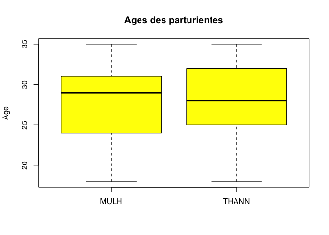

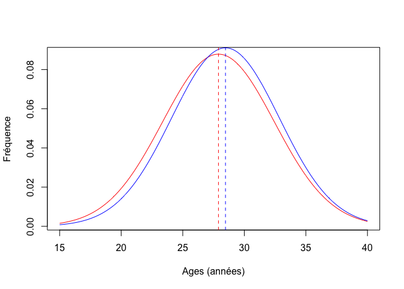

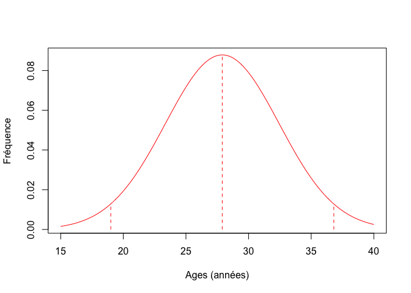

```
     MUL      TAN
28.86755 27.12289
```

```
    Two Sample t-test

data:  pop by mat
t = 1.9146, df = 98, p-value = 0.05845
alternative hypothesis: true difference in means is not equal to 0
95 percent confidence interval:
 -0.063619  3.552941
sample estimates:
mean in group MUL mean in group TAN
         28.86755          27.12289
```

## 2.3 IMC Calculé

```
   Min. 1st Qu.  Median    Mean 3rd Qu.    Max.    NA's
  16.03   20.94   22.70   23.88   25.80   34.89       2
```

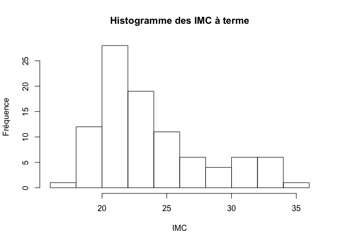

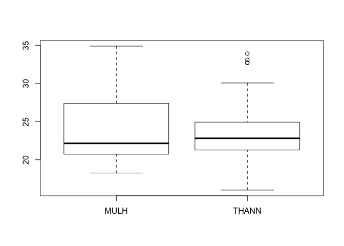

```
    Welch Two Sample t-test

data:  imc_calc by mat
t = 0.2404, df = 91.676, p-value = 0.8106
alternative hypothesis: true difference in means is not equal to 0
95 percent confidence interval:
 -1.555379  1.983723
sample estimates:
 mean in group MULH mean in group THANN
           23.97882            23.76465
```

## 2.4 Relation taille - poids

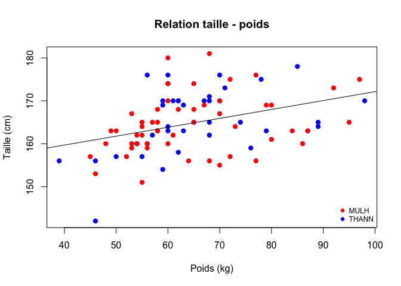

```
Call:
lm(formula = taille ~ poids_at, data = acc)

Residuals:
     Min       1Q   Median       3Q      Max
-18.9289  -4.5693  -0.4536   4.5372  16.1684

Coefficients:
            Estimate Std. Error t value Pr(>|t|)
(Intercept) 151.3914     3.5462  42.692  < 2e-16 ***
poids_at      0.2073     0.0536   3.869 0.000204 ***
---
Signif. codes:  0 '***' 0.001 '**' 0.01 '*' 0.05 '.' 0.1 ' ' 1

Residual standard error: 6.509 on 92 degrees of freedom
  (2 observations deleted due to missingness)
Multiple R-squared:  0.1399,    Adjusted R-squared:  0.1306
F-statistic: 14.97 on 1 and 92 DF,  p-value: 0.0002042
```

## 2.5 Prise de poids pendant la grossesse

```r
summary(acc$ppd)
```

```
##    Min. 1st Qu.  Median    Mean 3rd Qu.    Max.    NA's
##    1.00   10.00   12.00   12.17   15.00   27.00      15
```

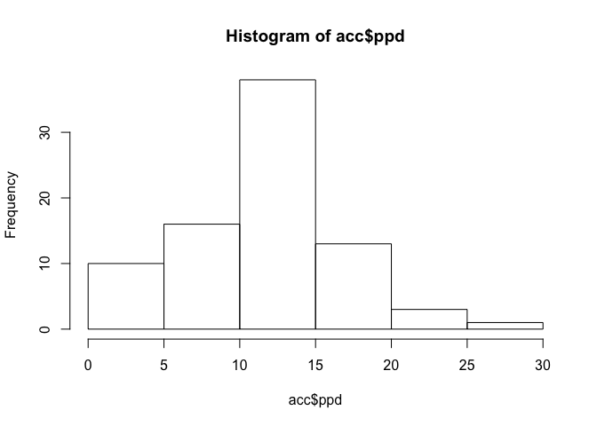

```r
hist(acc$ppd)
```

```r
# calcul du poids avant grossesse
pd_initial <- acc$poids_at - acc$ppd
summary(pd_initial) # il y a des poids bizarres
```

```
##    Min. 1st Qu.  Median    Mean 3rd Qu.    Max.    NA's
##   22.00   41.00   52.00   52.52   60.00   88.00      15
```

## 2.6 Dilatation du col à l’admission

```
   Min. 1st Qu.  Median    Mean 3rd Qu.    Max.
  1.000   4.000   4.000   4.719   6.000  10.000
```

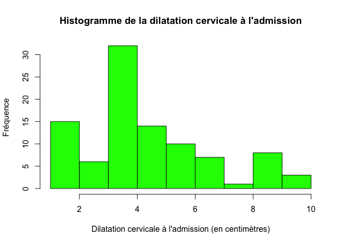

```
    Welch Two Sample t-test

data:  dil_adm by mat
t = -0.2048, df = 85.405, p-value = 0.8382
alternative hypothesis: true difference in means is not equal to 0
95 percent confidence interval:
 -1.067066  0.867765
sample estimates:
 mean in group MULH mean in group THANN
           4.673077            4.772727
```

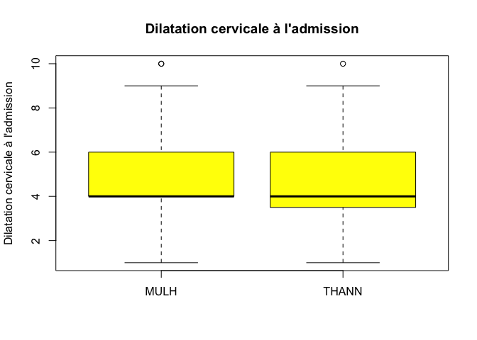

Durée entre la dilatation complète et les efforts expulsifs

```
   Min. 1st Qu.  Median    Mean 3rd Qu.    Max.    NA's
   0.00    2.00   10.00   35.62   55.00  204.00      17
```

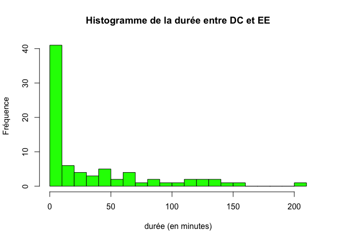

```
    Welch Two Sample t-test

data:  dur_dc_ee by mat
t = 2.6686, df = 62.312, p-value = 0.009697
alternative hypothesis: true difference in means is not equal to 0
95 percent confidence interval:
  6.434576 44.834255
sample estimates:
 mean in group MULH mean in group THANN
           46.97727            21.34286
```

[figure not shown]